# ET Analysis Part 1

TamTo

2024-02-04

# INTRODUCTION

This project involves analyzing proteomics data. Within this dataset, we have obtained relative abundance values that represent the expression of specific proteins in a sample. The purpose of this experiment is to compare protein expression between different samples.

Ultimately, analyzing protein abundances in proteomics data is crucial for elucidating biological markers, understanding protein regulation, and characterizing cellular processes under different biological conditinos.

## Background

Immune cells can release extracellular traps (ETs), which are structures composed of DNA, antimicrobial peptides, and other proteins. ETs can bind, capture, and neutralize pathogens, however, they have not yet been extensively studied in the skin.

Cutibacterium acnes (C. acnes) are a predominant bacterial species on the skin known for inducing formation of ETs. C. acnes are associated with acne pathogenesis, and it has been shown that they can induce T cell extracellular trap (TET) formation by antimicrobial T helper 17 (Th17) cells [(Agak et al., 2021)](https://www.jci.org/articles/view/141594).

While TETs play a pivotal role in host defense against C. acnes, their mechanism of action and contribution to immune response against pathogens in the skin remain unknown. C. acnes phylotypes can induce different immune responses, so they may trigger the release of ETs that can be either protective or contribute to inflammatory response.

Therefore, investigating the important molecular factors that make up C. acnes-induced ETs can provide insights for developing targeted therapeutic strategies to manage acne vulgaris and maintain skin homeostasis. Within this dataset, we are analyzing 4 conditions of TETs induced by antimicrobial Th17 cells:

- TETs formed spontaneously
- TETs induced by phorbol 12-myristate 13-acetate (PMA)
- Acne-associated C. acnes strain
- Healthy-associated C. acnes strain

> We hypothesize that TETs induced by different stimuli have distinct protein compositions. This analysis will shed light on the intricate balance between the skin microbiome and immune system in regulating skin health.

**To ensure privacy of the data (since it is not yet available publicly), some results are hidden.**

```r
library(tidyverse)
library(writexl)
library(readxl)

setwd("/Users/tamto/Documents/GitHub/MolecularBiologyProjects/Projects/Project_ProteomicsAnalysis")

# Load the data
TETs <- read_excel("/Users/tamto/Desktop/Proteomics/TETs_Proteins.xlsx")
```

# Select and Clean the Data

The dataset has a LOT of information (i.e. full gene ID names, biological processes, ratios, cellular components, ratios, etc.) along with NA values. Since this analysis uses the abundance values and protein IDs, I’m going to clean it up a bit.

When I was prepping these samples, I made replicates of each condition (all conditions normalized with the same amount of cells). The samples are as follows:

- Spontaneous: T1-T3
- PMA: T4-T6
- CA (acne-associated strain): T7-T9
- CH (healthy-associated strain): T10-T12

```r
# Inspect the data
#str(TETs)
dim(TETs)
```

```
## [1] 1397   75
```

```r
head(TETs)
```

```
## # A tibble: 6 × 75
##   Checked `Protein FDR Confidence: Combined` Master        Accession Description
##   <lgl>   <chr>                              <chr>         <chr>     <chr>
## 1 FALSE   High                               Master Prote… P35579    Myosin-9 […
## 2 FALSE   High                               Master Prote… P04114    Apolipopro…
## 3 FALSE   High                               Master Prote… P21333    Filamin-A …
## 4 FALSE   High                               Master Prote… P60709    Actin, cyt…
## 5 FALSE   High                               Master Prote… P02768    Albumin [O…
## 6 FALSE   High                               Master Prote… P02751    Fibronecti…
## # ℹ 70 more variables: `Exp. q-value: Combined` <dbl>, `Sum PEP Score` <dbl>,
## #   `Coverage [%]` <dbl>, `# Peptides` <dbl>, `# PSMs` <dbl>,
## #   `# Unique Peptides` <dbl>, `# AAs` <dbl>, `MW [kDa]` <dbl>,
## #   `calc. pI` <dbl>, `Score Sequest HT: Sequest HT` <dbl>,
## #   `# Peptides (by Search Engine): Sequest HT` <dbl>,
## #   `Biological Process` <chr>, `Cellular Component` <chr>,
## #   `Molecular Function` <chr>, `Pfam IDs` <chr>, `Entrez Gene ID` <chr>, …
```

```r
# Select Abundances from each sample for analysis
TETs_Abundances <- TETs %>%
  select('Gene Symbol', starts_with("Abundances (Grouped):"))

#It's also important to remember to omit the Gene Symbol rows with NA
TETs_Abundances <- TETs_Abundances %>%
  drop_na('Gene Symbol')

# Select for groups of interest (Spontaneous, PMA, CA, CH induced TETs)
TETs_Abundances_filter <- TETs_Abundances %>%
  select(-c("Abundances (Grouped): E1", "Abundances (Grouped): E2", "Abundances (Grouped): E3"))

# Rename the columns so they're easier to work with
new_columns <- c("Gene", "T1", "T2", "T3",
                 "T4", "T5", "T6",
                 "T7", "T8", "T9",
                 "T10", "T11", "T12")

colnames(TETs_Abundances_filter)[1:13] <- new_columns

colnames(TETs_Abundances_filter)
```

```
##  [1] "Gene" "T1"   "T2"   "T3"   "T4"   "T5"   "T6"   "T7"   "T8"   "T9"
## [11] "T10"  "T11"  "T12"
```

```r
# Remove rows where there is NA across all the samples
TETs_Abundances_filter <- TETs_Abundances_filter %>%
  filter(!rowSums(is.na(select(TETs_Abundances_filter, starts_with("T")))) == ncol(select(TETs_Abundances_filter, starts_with("T"))))

# Find expression of proteins in at least 2/3 of each replicate across all conditions together
replicates <- TETs_Abundances_filter %>%
  filter(
    rowSums(is.na(select(TETs_Abundances_filter, c(T1, T2, T3)))) < 2 &
    rowSums(is.na(select(TETs_Abundances_filter, c(T4, T5, T6)))) < 2 &
    rowSums(is.na(select(TETs_Abundances_filter, c(T7, T8, T9)))) < 2 &
    rowSums(is.na(select(TETs_Abundances_filter, c(T10, T11, T12)))) < 2
  )

# Rename the columns to each sample replicate name
renamed_columns <- c("Spon1", "Spon2", "Spon3",
                     "PMA1", "PMA2", "PMA3",
                     "CA1", "CA2", "CA3",
                     "CH1", "CH2", "CH3")

colnames(replicates)[2:13] <- renamed_columns
```

I’ve selected the necessary data for analysis and renamed the sample replicates for clarity.

# Handling Missing Data

From selecting the sample with values in at least 2/3 of the replicates, we need to impute the missing data. Below, I’m choosing the k-nearest neighbors (kNN) method to do so.

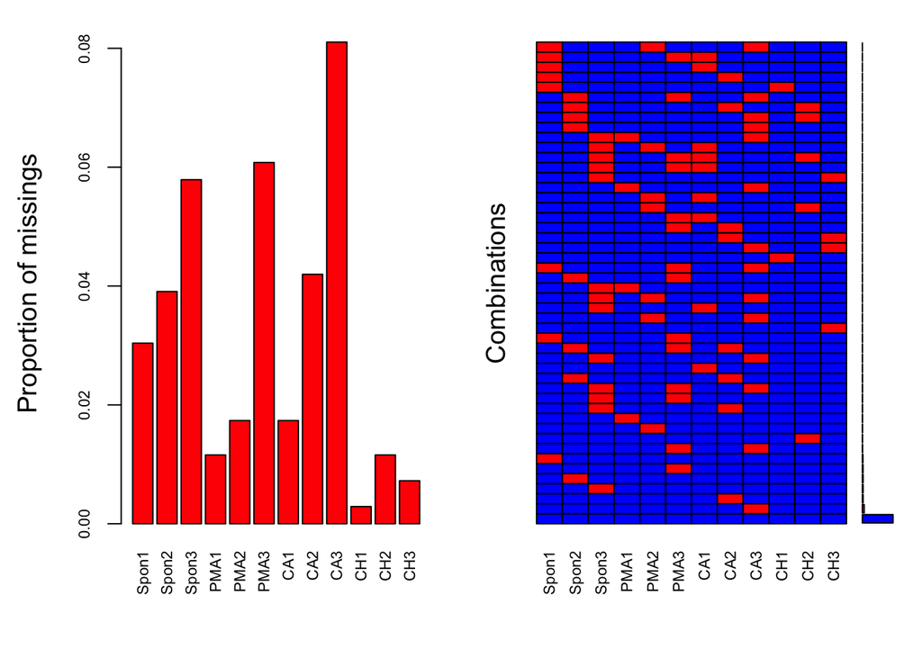

```r
# install VIM
# install.packages("VIM")

# Load VIM package
library(VIM)

# Explore and visualize missing data patterns
aggr(replicates[,-1], numbers = TRUE, col = c("blue", "red"),
     labels = names(data), cex.axis = 0.7)
```

```r
# Choose an imputation method (e.g., k-nearest neighbors)
imputed_data <- kNN(replicates)
imputed_data <- imputed_data[1:13]

# Evaluate imputed data. No more missing values.
summary(imputed_data)
```

```
##      Gene               Spon1               Spon2               Spon3
##  Length:691         Min.   :5.140e+03   Min.   :1.431e+03   Min.   :3.743e+03
##  Class :character   1st Qu.:4.339e+05   1st Qu.:3.828e+05   1st Qu.:4.214e+05
##  Mode  :character   Median :1.237e+06   Median :1.199e+06   Median :1.254e+06
##                     Mean   :3.517e+07   Mean   :3.710e+07   Mean   :3.487e+07
##                     3rd Qu.:4.458e+06   3rd Qu.:4.698e+06   3rd Qu.:4.533e+06
##                     Max.   :8.984e+09   Max.   :9.371e+09   Max.   :9.045e+09
##       PMA1                PMA2                PMA3
##  Min.   :8.130e+03   Min.   :2.841e+03   Min.   :3.711e+03
##  1st Qu.:1.171e+06   1st Qu.:5.515e+05   1st Qu.:4.629e+05
##  Median :3.663e+06   Median :1.585e+06   Median :1.368e+06
##  Mean   :4.865e+07   Mean   :2.992e+07   Mean   :3.363e+07
##  3rd Qu.:1.226e+07   3rd Qu.:5.135e+06   3rd Qu.:5.066e+06
##  Max.   :9.514e+09   Max.   :7.338e+09   Max.   :7.967e+09
##       CA1                 CA2                 CA3
##  Min.   :6.675e+03   Min.   :4.895e+04   Min.   :2.576e+03
##  1st Qu.:8.142e+05   1st Qu.:5.189e+05   1st Qu.:5.036e+05
##  Median :2.538e+06   Median :1.542e+06   Median :1.323e+06
##  Mean   :4.291e+07   Mean   :3.498e+07   Mean   :3.437e+07
##  3rd Qu.:8.183e+06   3rd Qu.:5.497e+06   3rd Qu.:4.903e+06
##  Max.   :8.379e+09   Max.   :7.927e+09   Max.   :7.557e+09
##       CH1                 CH2                 CH3
##  Min.   :6.051e+03   Min.   :2.646e+04   Min.   :4.038e+03
##  1st Qu.:2.309e+06   1st Qu.:1.936e+06   1st Qu.:2.174e+06
##  Median :6.750e+06   Median :5.775e+06   Median :6.401e+06
##  Mean   :6.036e+07   Mean   :4.760e+07   Mean   :5.126e+07
##  3rd Qu.:2.229e+07   3rd Qu.:1.846e+07   3rd Qu.:2.047e+07
##  Max.   :7.632e+09   Max.   :5.759e+09   Max.   :6.531e+09
```

```r
any(is.na(imputed_data))
```

```
## [1] FALSE
```

```r
# save the data
# write_xlsx(imputed_data, "imputed_data.xlsx")
```

Next I’m standardizing the data to perform Principal Component Analysis (PCA). First to find the k-value, we create an elbow plot.

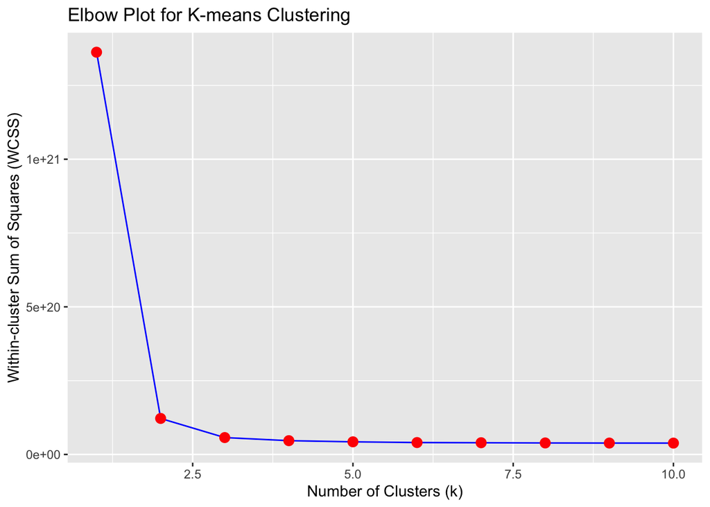

```r
na_TETs <- na.omit(TETs_Abundances_filter)

# Calculate WCSS for different k values. WCSS is the within-cluster sum of square distance between each point and the centroid in a cluster. When we plot WCSS with the k-value, the plot looks like an elbow. As cluster size increases, the WCSS value will start to decrease. K-value at the elbow is optimal value of K (i.e. optimal number of clusters).
wcss_values <- NULL
for (k in 1:10) {
  kmeans_model <- kmeans(na_TETs[, -1], centers = k)
  wcss_values <- c(wcss_values, kmeans_model$tot.withinss)
}

# Create dataframe for plotting
elbow_data <- data.frame(k = 1:10, WCSS = wcss_values)

# Plot elbow plot
ggplot(elbow_data, aes(x = k, y = WCSS)) +
  geom_line(color = "blue") +
  geom_point(color = "red", size = 3) +
  labs(title = "Elbow Plot for K-means Clustering",
       x = "Number of Clusters (k)",
       y = "Within-cluster Sum of Squares (WCSS)")
```

```r
# Arranging by the total sum across rows from the replicates df
replicates <- replicates %>%
  mutate(Total = rowSums(replicates[,2:13])) %>%
  arrange(desc(Total)) %>%
  select(-Total)


# Inspect missing values in each column
missing_count <- colSums(is.na(replicates))

# Print the result
print(missing_count)
```

```
##  Gene Spon1 Spon2 Spon3  PMA1  PMA2  PMA3   CA1   CA2   CA3   CH1   CH2   CH3
##     0    21    27    40     8    12    42    12    29    56     2     8     5
```

```r
# Load necessary library
library(caret)

# Perform k-NN imputation. preProcess() automatically ignores non-numeric columns.
preProcValues <- preProcess(replicates,
                            method = "knnImpute",
                            k = 1.7)  # Choose an appropriate k value based on elbow plot
                           #knnSummary = mean)

standardized_imputed_values <- predict(preProcValues, replicates)

# Apply imputation to the entire dataset
standardized_imputed_values <- predict(preProcValues, replicates)

# Check if there are any missing values now
any(is.na(standardized_imputed_values))
```

```
## [1] FALSE
```

```r
# write_xlsx(standardized_imputed_values, "standardized_imputed_data.xlsx")
```

Here we want to perform PCA on the dataset as a preprocessing step for data visualization techniques and to reduce dimensionality.

```r
head(standardized_imputed_values)
```

```
## # A tibble: 6 × 13
##   Gene        Spon1  Spon2  Spon3   PMA1   PMA2   PMA3   CA1    CA2    CA3   CH1
##   <chr>       <dbl>  <dbl>  <dbl>  <dbl>  <dbl>  <dbl> <dbl>  <dbl>  <dbl> <dbl>
## 1 ALB        20.1   19.6   20.5   19.4   20.6   19.6   19.7  20.6   19.6   17.1
## 2 AHSG       15.5   16.0   14.4   16.4   15.2   15.3   15.8  14.5   14.9   16.4
## 3 PATJ        4.07   4.18   4.08   3.12   3.79   4.63   4.27  3.71   3.60   2.20
## 4 H4C1; H4C…  0.555  0.588  0.291  2.45   0.905  0.655  2.05  0.880  0.968  8.07
## 5 ACTB        1.32   0.920  1.11   3.84   1.91   1.49   1.91  1.07   0.933  5.36
## 6 HBA1; HBA2  0.770  0.844  0.984  0.586  0.748  1.03   1.99  2.02   1.98   1.22
## # ℹ 2 more variables: CH2 <dbl>, CH3 <dbl>
```

```r
#load
library("factoextra")
library("FactoMineR")

# make sure no NAs
any(is.na(standardized_imputed_values))
```

```
## [1] FALSE
```

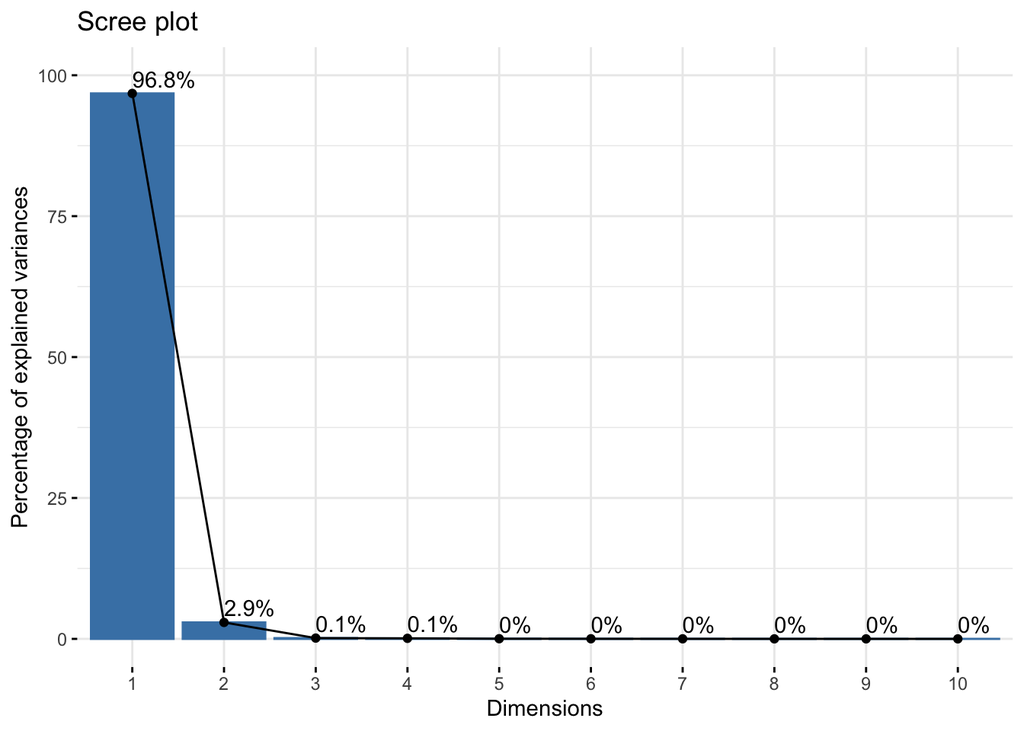

```r
#pca_proteins[,-1] to omit first column from our analysis bc these are the genes and aren't the numeric values. scale.unit = standardizing the values
pca.data <- PCA(standardized_imputed_values[,-1], scale.unit = TRUE, graph = FALSE)

# scree plot
fviz_eig(pca.data, addlabels = TRUE, ylim = c(0, 100))
```

The first PC explains 96.8% of the variation, 2nd PC explains 2.9%

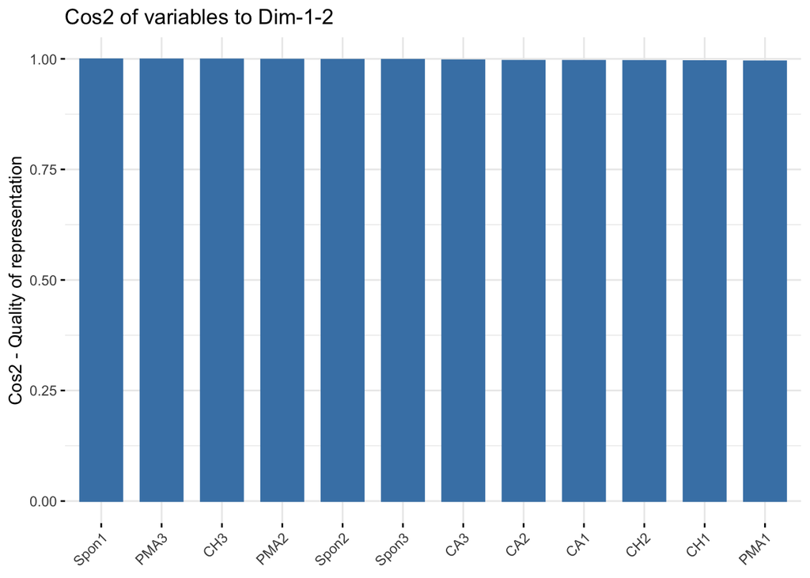

```r
# cos2 is squared cosine --> high = indicates good representation of the variable on the PC, low = variable not perfectly represented by the PCs. Cos2 determines how much each variable is represented in a given component, low = variable not perfectly represented by the component, high = good representation of the variable on that component
fviz_cos2(pca.data, choice = "var", axes = 1:2)
```

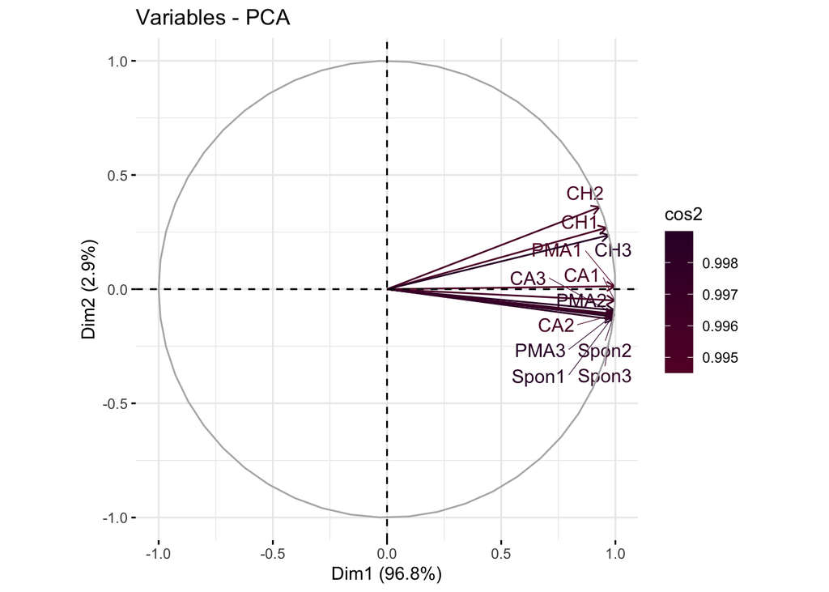

```r
# draw variable correlation plot
fviz_pca_var(pca.data, col.var = "cos2",
             gradient.cols = c("#660033", "#330033"),
             repel = TRUE)
```

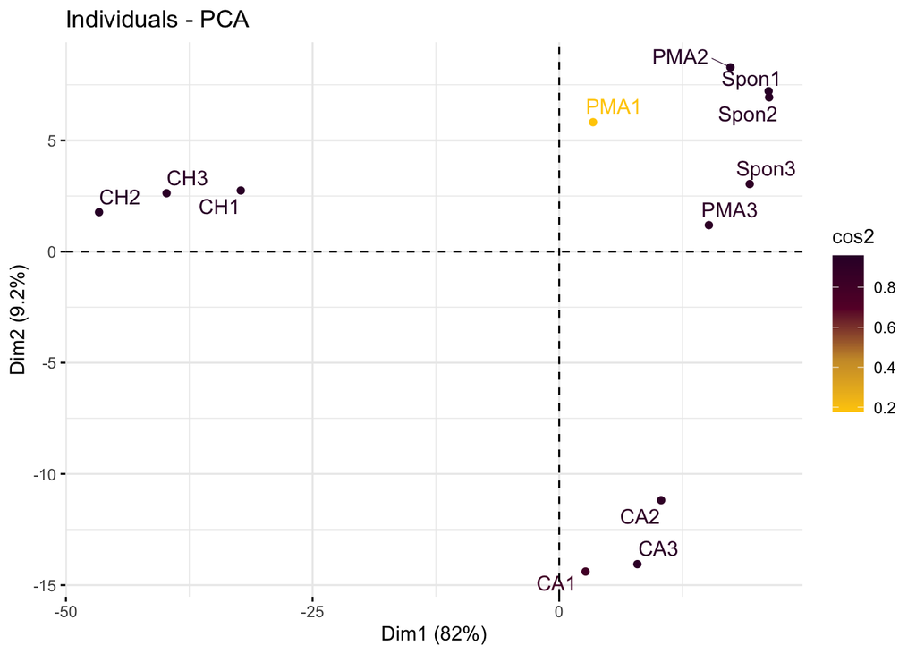

```r
# each sample is correlated to each other since they are next to each other on the plot (no negative correlation otherwise the arrow would be on the opposite side)

# plot cell types and flip the table to put cell types as rows
pca.data.ind <- PCA(t(standardized_imputed_values[,-1]), scale.unit = TRUE, graph = FALSE)


fviz_pca_ind(pca.data.ind, col.ind = "cos2",
                  gradient.cols = c("#FFCC00", "#CC9933", "#660033", "#330033"),
                  repel = TRUE)
```

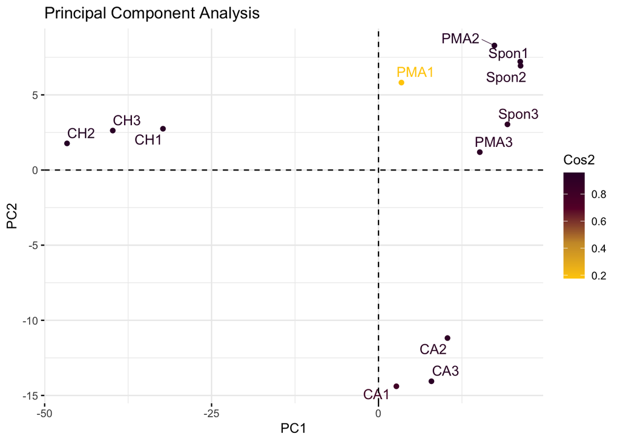

```r
# Edit the graph
library(ggpubr)

a <- fviz_pca_ind(pca.data.ind, col.ind = "cos2",
                  gradient.cols = c("#FFCC00", "#CC9933", "#660033", "#330033"),
                  repel = TRUE)

ggpar(a,
      title = "Principal Component Analysis",
      xlab = "PC1", ylab = "PC2",
      legend.title = "Cos2", legend.position = "top",
      ggtheme = theme_minimal())
```

# Observing Relative Protein Abundances

Here we calculate the relative frequency of protein abundance values by calculating the proportion of occurrences relative to the total number of observations.

```r
#row sums
imputed_data$row_sum <- rowSums(imputed_data[, 2:13])

# Calculate frequencies for each sample column
for (sample_col in c("Spon1", "Spon2", "Spon3",
                     "PMA1", "PMA2", "PMA3",
                     "CA1", "CA2", "CA3",
                     "CH1", "CH2", "CH3")) {
  freq_col <- paste0("freq_", sample_col)
  imputed_data[[freq_col]] <- imputed_data[[sample_col]] / imputed_data$row_sum
}

# find the average of the abundances
imputed_data <- imputed_data %>%
  mutate(
    Spontaneous = rowMeans(select(imputed_data, c(Spon1, Spon2, Spon3)), na.rm = TRUE),
    PMA = rowMeans(select(imputed_data, c(PMA1, PMA2, PMA3)), na.rm = TRUE),
    CA = rowMeans(select(imputed_data, c(CA1, CA2, CA3)), na.rm = TRUE),
    CH = rowMeans(select(imputed_data, c(CH1, CH2, CH3)), na.rm = TRUE)
  )

# write_xlsx(imputed_data, "abundance_frequencies.xlsx")
```

## Histogram

Distribution of the relative frequencies can be visualized via histograms.

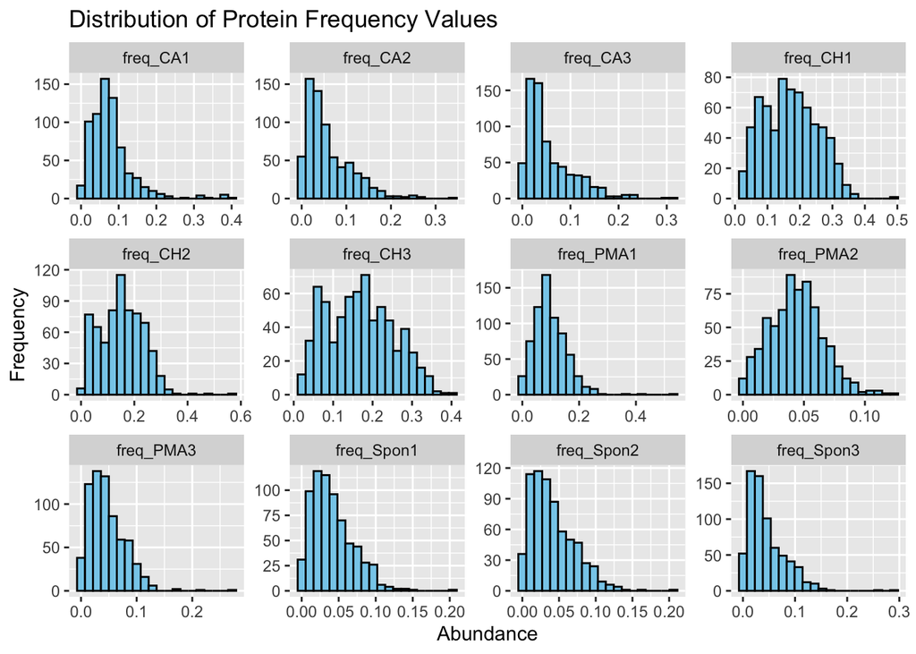

```r
# Select frequency data
frequency_data <- imputed_data %>%
  select(Gene, starts_with("freq"))

# Reshape dataframe from wide to long format
df_long <- frequency_data %>%
  pivot_longer(cols = starts_with("freq_Spon") | starts_with("freq_PMA") | starts_with("freq_CA") | starts_with("freq_CH"),
               names_to = "Condition",
               values_to = "Abundance")

# Create histogram
ggplot(df_long, aes(x = Abundance)) +
  geom_histogram(fill = "skyblue", color = "black", bins = 20) +
  facet_wrap(~ Condition, scales = "free") +
  labs(x = "Abundance", y = "Frequency", title = "Distribution of Protein Frequency Values")
```

We see that Spontaneous, PMA, and CA samples are skewed to the right. CH samples have more higher frequency values.

## Violin Plot

Violin plots are another method of showing distribution.

```r
colnames(imputed_data)
```

```
##  [1] "Gene"        "Spon1"       "Spon2"       "Spon3"       "PMA1"
##  [6] "PMA2"        "PMA3"        "CA1"         "CA2"         "CA3"
## [11] "CH1"         "CH2"         "CH3"         "row_sum"     "freq_Spon1"
## [16] "freq_Spon2"  "freq_Spon3"  "freq_PMA1"   "freq_PMA2"   "freq_PMA3"
## [21] "freq_CA1"    "freq_CA2"    "freq_CA3"    "freq_CH1"    "freq_CH2"
## [26] "freq_CH3"    "Spontaneous" "PMA"         "CA"          "CH"
```

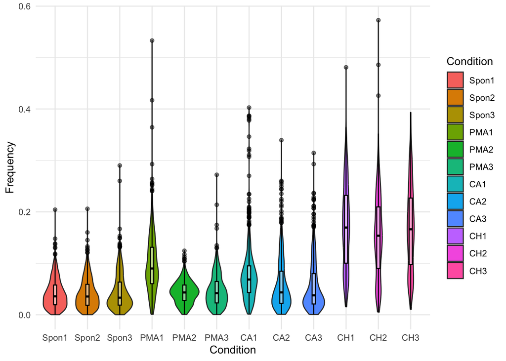

```r
# Select the columns that include the frequencies
violin_data <- imputed_data %>%
  select(Gene, 15:26)


rename_col <- c("Spon1", "Spon2", "Spon3",
                        "PMA1", "PMA2", "PMA3",
                        "CA1", "CA2", "CA3",
                        "CH1", "CH2", "CH3")

colnames(violin_data)[2:13] <- rename_col

# Reshape the dataframe using tidyr's pivot_longer function
violin_data_long <- violin_data %>%
  pivot_longer(cols = -Gene, names_to = "Condition", values_to = "Abundance")

# Order the sample replicates
violin_data_long$Condition <- factor(violin_data_long$Condition, levels = c(
  paste0("Spon", 1:3),
  paste0("PMA", 1:3),
  paste0("CA", 1:3),
  paste0("CH", 1:3)
))

# Plot violin plot using ggplot2
ggplot(violin_data_long, aes(x = Condition, y = Abundance, fill = Condition)) +
  geom_violin() +
  geom_boxplot(width = 0.1, fill = "white", color = "black", alpha = 0.5) + # Add boxplot overlay for clearer representation
  labs(x = "Condition", y = "Frequency") +
  theme_minimal()
```

We see the same pattern here too.

## Heatmap

Here we can get insights from relative protein abundances via plotting on a heatmap. I’m going to use z-scores as a normalization method to standardize the protein abundances across samples and compare between proteins.

Earlier we computed the average abundance values for each sample condition, so I’m going to use those.

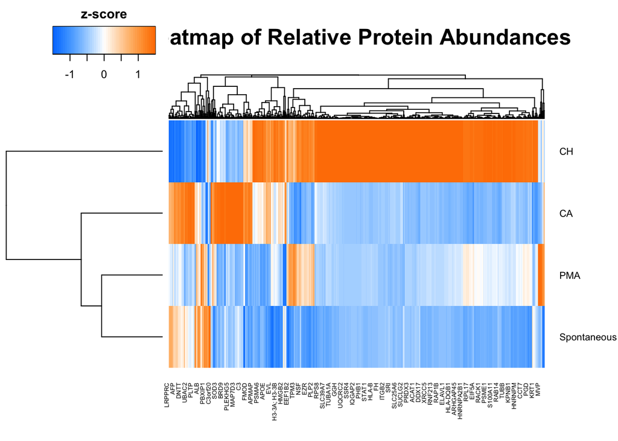

```r
# Select the
abundances <- imputed_data %>%
  select(Gene, 27:30)

# Make the heatmap using the protein abundance frequency values
abundances_df <- abundances %>%
  remove_rownames %>%
  column_to_rownames(var="Gene")

# Change df into a matrix
abundances_matrix <- as.matrix(abundances_df)

# Calculate z-scores
row_stdev <- apply(abundances_matrix, 1, sd, na.rm=TRUE) # find row SD
row_mean <- rowMeans(abundances_matrix, na.rm = T) # find row means
z_scores <- (abundances_matrix-row_mean)/row_stdev # compute z-scores

# Turn into matrix, ensure no NAs
z_scores_matrix <- z_scores %>%
  as.matrix() %>%
  na.omit()

# transpose because there are a lot of proteins
transposed_matrix <- t(z_scores_matrix)

# load necessary library
library(gplots)
# adjust colors
custom_blue <- rgb(0, 0.5, 1)
custom_red <- rgb(1, 0.5, 0)

heatmap.2(transposed_matrix,
          main = "Heatmap of Relative Protein Abundances",
          col = colorRampPalette(c(custom_blue, "white", custom_red))(50),
          cexRow = .8, # adjust font size of x-axis labels
          cexCol = 0.5,  # Adjust the font size of y-axis labels
          key.title = "z-score",  # Legend title
          key.xlab = "",  # Remove x-axis label
          key.ylab = "",  # Remove y-axis label
          keysize = 1.5,  # Adjust legend size
          density.info = "none",  # Remove density plot
          trace = "none")
```

We see that proteins are differentially expressed across samples/conditions.

# CONCLUSION

In this project, we first set a goal from our experimental data. Next we inspected, cleaned, and preprocessed the data using different machine learning and statistical methods. We were able to create visualizations from the results of these analyses as well.

In Part 2, we use this data to perform more analyses to help us understand more about the data we obtained. We can formulate both descriptive and predictive insights about ETs in acne.